# FigureYa12 box

**Author(s)**: Guangchuang Yu; Ying Ge, Yijing Chen  
**Date**: 2025-12-13

[figure not shown]

# Academic Citation

If you use this code in your work or research, we kindly request that you cite our publication:

Xiaofan Lu, et al. (2025). FigureYa: A Standardized Visualization Framework for Enhancing Biomedical Data Interpretation and Research Efficiency. iMetaMed. https://doi.org/10.1002/imm3.70005

## 需求描述

## Requirement description

用R代码画出paper里的图

Drawing plots in paper with R code

图1

Figure 1

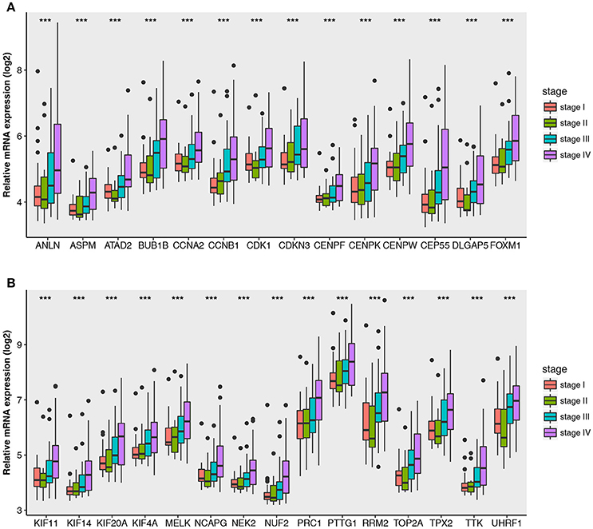

图2

Figure 2

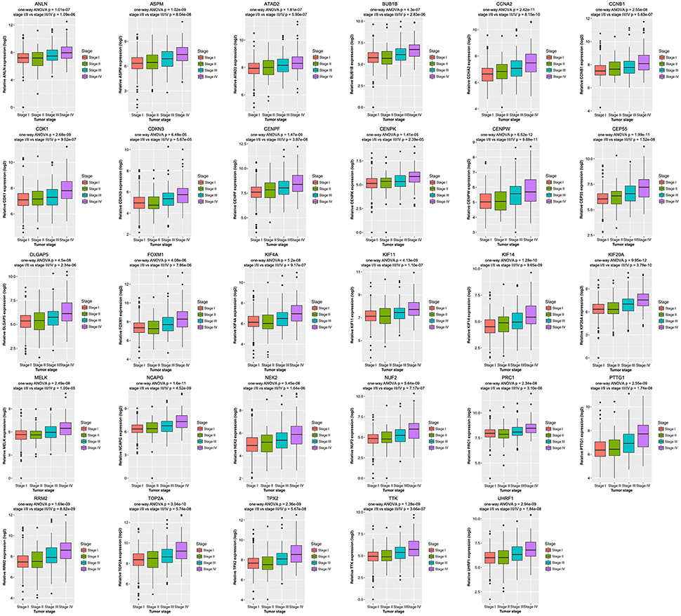

出自https://www.frontiersin.org/articles/10.3389/fphys.2018.00399/full

fromhttps://www.frontiersin.org/articles/10.3389/fphys.2018.00399/full

## 使用场景

## Usage scenario

用boxplot展示基因表达量分布，同时计算p value。

Use a boxplot to show the distribution of gene expression and calculate the p-value.

## 输入数据

## Input data

### 1. 基因表达量列表

### 1. gene expression list

easy_input_expr.csv，多个sample中所有基因的表达量。

包含stage1, stage2, stage3，各10个样本，stage以样本名后面`_数字`标识。

easy_input_expr.csv, expression of all genes in multiple samples.

It includes stage1, stage2, and stage3, with 10 samples each. Stage is indicated by `_number` following the sample name.

```r
source("install_dependencies.R")
```

```
## Starting R package installation...
## ===========================================
##
## Installing CRAN packages...
## Package already installed: cowplot
## Package already installed: ggplot2
## Package already installed: tidyr
##
## ===========================================
## Package installation completed!
## You can now run your R scripts in this directory.
```

```r
require(ggplot2)
require(tidyr)
require(cowplot)
d <- read.csv("easy_input_expr.csv", row.names=1)
dim(d)
```

```
## [1] 12403    30
```

```r
head(d)
```

```
##       MAINZ_BC6092_1 MAINZ_BC6097_1 MAINZ_BC6100_1 MAINZ_BC6218_1
## NAT2        4.425626       4.611533       4.894555       4.562204
## ADA         7.987913       7.948158       8.525834       8.690879
## CDH2        5.197918       2.616437       5.554450       7.377561
## AKT3       10.552171       8.944986      10.260511      10.646781
## MED6        6.571640       4.824795       6.025742       4.838854
## NR2E3       3.219911       4.125825       3.886830       3.661139
##       MAINZ_BC6177_1 MAINZ_BC6044_1 MAINZ_BC6147_1 MAINZ_BC6054_1
## NAT2        4.843748       5.333067       7.692409       4.340142
## ADA         8.574520       8.411314       7.920857       7.403979
## CDH2        5.538262       6.378720       6.388747       6.306310
## AKT3        9.664998       9.776856       9.247663       9.540841
## MED6        6.468880       3.805689       5.506055       5.836874
## NR2E3       2.617223       2.594023       2.745115       3.073157
##       MAINZ_BC6189_1 MAINZ_BC6033_1 MAINZ_BC6045_2 MAINZ_BC6048_2
## NAT2        4.795472       3.995223       7.340844       4.892963
## ADA         8.298271       8.282437       7.859992       8.549702
## CDH2        7.090367       7.190526       5.647097       5.466852
## AKT3       11.129074       9.783980       9.635014       9.306182
## MED6        5.162044       4.991537       5.383359       6.000691
## NR2E3       3.045446       3.794829       2.930630       2.908441
##       MAINZ_BC6130_2 MAINZ_BC6126_2 MAINZ_BC6101_2 MAINZ_BC6020_2
## NAT2        3.889378       7.178431       6.438616       3.889646
## ADA         8.334130       8.996667       8.024937       8.167574
## CDH2        3.267584       7.359152       8.393634       7.024651
## AKT3        9.811217       9.316309      10.012914       9.983047
## MED6        6.083501       4.757090       5.175474       4.060210
## NR2E3       2.872831       3.216402       2.890781       2.660714
##       MAINZ_BC6170_2 MAINZ_BC6145_2 MAINZ_BC6192_2 MAINZ_BC6164_2
## NAT2        5.697533       4.587117       4.722770       4.755983
## ADA         8.911051       7.598076       8.530404       8.298648
## CDH2        6.150108       5.615339       4.950801       6.466362
## AKT3        9.964318       9.817005      10.074441      10.040906
## MED6        4.958310       4.577520       5.814101       3.896821
## NR2E3       3.211979       2.504005       5.615643       2.627402
##       MAINZ_BC6017_3 MAINZ_BC6081_3 MAINZ_BC6132_3 MAINZ_BC6105_3
## NAT2        4.324673       4.936396       5.448738       4.614386
## ADA         7.188407       8.452279       8.022264       8.405780
## CDH2        4.713701       5.789289       6.616463       7.448405
## AKT3       11.223955       9.458304       8.733822       9.014535
## MED6        5.713091       5.355615       5.629448       1.886849
## NR2E3       3.190783       3.971651       3.010863       3.492051
##       MAINZ_BC6183_3 MAINZ_BC6095_3 MAINZ_BC6060_3 MAINZ_BC6003_3
## NAT2        5.675163       8.279418       5.320667       4.554178
## ADA         9.269717       8.373910       9.291954       8.429090
## CDH2        3.823703       6.122847       4.857962       6.736505
## AKT3       10.518350       9.499518      11.077096       9.636981
## MED6        5.375877       4.912055       1.879677       5.043207
## NR2E3       2.998314       3.126517       2.944705       3.589710
##       MAINZ_BC6008_3 MAINZ_BC6174_3
## NAT2        3.773704       5.653681
## ADA         8.685586       9.440888
## CDH2        7.572518       6.701930
## AKT3        9.216117      10.477382
## MED6        4.647659       2.505383
## NR2E3       3.208616       4.118886
```

总共有12403个基因的表达量

There are 12403 gene expression in total

### 2. 差异表达的基因名列表

### 2. list of differentially expressed gene names

单独一列基因名；

或者第一列是基因名，后面是其他信息。

a single column of gene names;

Or the first column is the gene name followed by other information.

```r
up<-read.table("easy_input_up.txt",header = T, as.is = T, row.names = 1)
down<-read.table("easy_input_down.txt",header = T, as.is = T, row.names = 1)
```

## 开始画图

## Start drawing

### 1. 多组画在同一个绘图区域

### 1. multiple groups in the same drawing area

分别绘制上下调的基因，然后用cowplot来拼。

Draw the upregulated and downregulated genes separately, then combine them using cowplot.

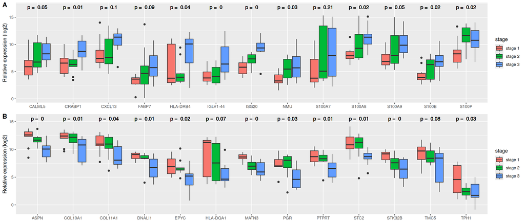

```r
require(tidyr)
require(ggplot2)

box <- lapply(list(up=row.names(up), down=row.names(down)), function(ii) {
    dd <- d[ii,]
    dd$gene = rownames(dd)

    ## 宽变长，变成tidy data frame，好用于ggplot2画图
    ## The width becomes length and becomes tidy data frame, which is easy to use for ggplot2 drawing.
    d2 <- gather(dd, sample, expr, 1:30)

    ## 通过sample名，衍生出stage变量
    ## derive the stage variable from the sample name
    d2$stage <- paste('stage', sub(".*_(\\d)$", "\\1", d2$sample))

    ## 用one way anova计算 p value
    ## calculate p value with one way anova
    pvalues <- sapply(d2$gene, function(x) {
        res <- aov(expr ~ stage, data = subset(d2, gene == x))
        summary(res)[[1]]$'Pr(>F)'[1] #
    })
    pv <- data.frame(gene = d2$gene, pvalue = pvalues)

    ## 画boxplot，并标识p-value
    ## draw boxplot and identify p-value
    ggplot(d2, aes(gene, expr, fill=stage)) +
      geom_boxplot() +
      geom_text(aes(gene, y=max(d2$expr) * 1.1,
                    label=paste("p = ",round(pvalue, 2))),
                data=pv, #
                inherit.aes=F) + #
      xlab(NULL)+ylab("Relative expression (log2)")
})

#拼图
#pictures put together
require(cowplot)
plot_grid(plotlist=box, labels=c("A", "B"), ncol=1)
```

```r
#保存到pdf文件
#save as pdf file
ggsave(file="box1.pdf")
```

把pvalue变成sigcode，然后再下面画图代码中`label=paste("p = ",round(pvalue, 2))`标记p值的地方，改成`label = sigcode`即可。

Change p-value to sigcode, and then in the plotting code below, change `label=paste("p = ",round(pvalue, 2))` where the p-value is labeled to `label = sigcode`.

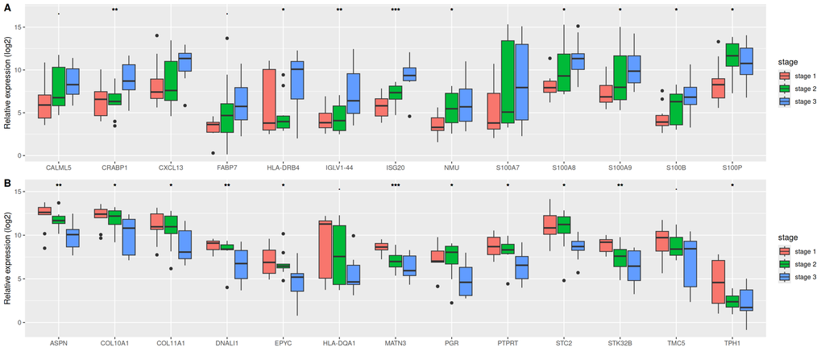

```r
box <- lapply(list(up=row.names(up), down=row.names(down)), function(ii) {
    dd <- d[ii,]
    dd$gene = rownames(dd)
    d2 <- gather(dd, sample, expr, 1:30)
    d2$stage <- paste('stage', sub(".*_(\\d)$", "\\1", d2$sample))
    pvalues <- sapply(d2$gene, function(x) {
        res <- aov(expr ~ stage, data = subset(d2, gene == x))
        summary(res)[[1]]$'Pr(>F)'[1] #
    })
    pv <- data.frame(gene = d2$gene, pvalue = pvalues)

    ## Signif. codes:  0 ‘***’ 0.001 ‘**’ 0.01 ‘*’ 0.05 ‘.’ 0.1 ‘ ’ 1
    pv$sigcode <- cut(pv$pvalue, c(0, 0.001, 0.01, 0.05, 0.1, 1),
                    labels=c('***', '**', '*', '.', ' '))

    ggplot(d2, aes(gene, expr, fill=stage)) +
      geom_boxplot() +
      geom_text(aes(gene, y=max(d2$expr) * 1.1,
                    label=pv$sigcode),
                data=pv, inherit.aes=F) +
      xlab(NULL)+ylab("Relative expression (log2)")
})

require(cowplot)
plot_grid(plotlist=box, labels=c("A", "B"), ncol=1)
```

```r
ggsave(file="box2.pdf")
```

### 2. 多个小图拼成一个大图

### 2. Multiple small images into one large image

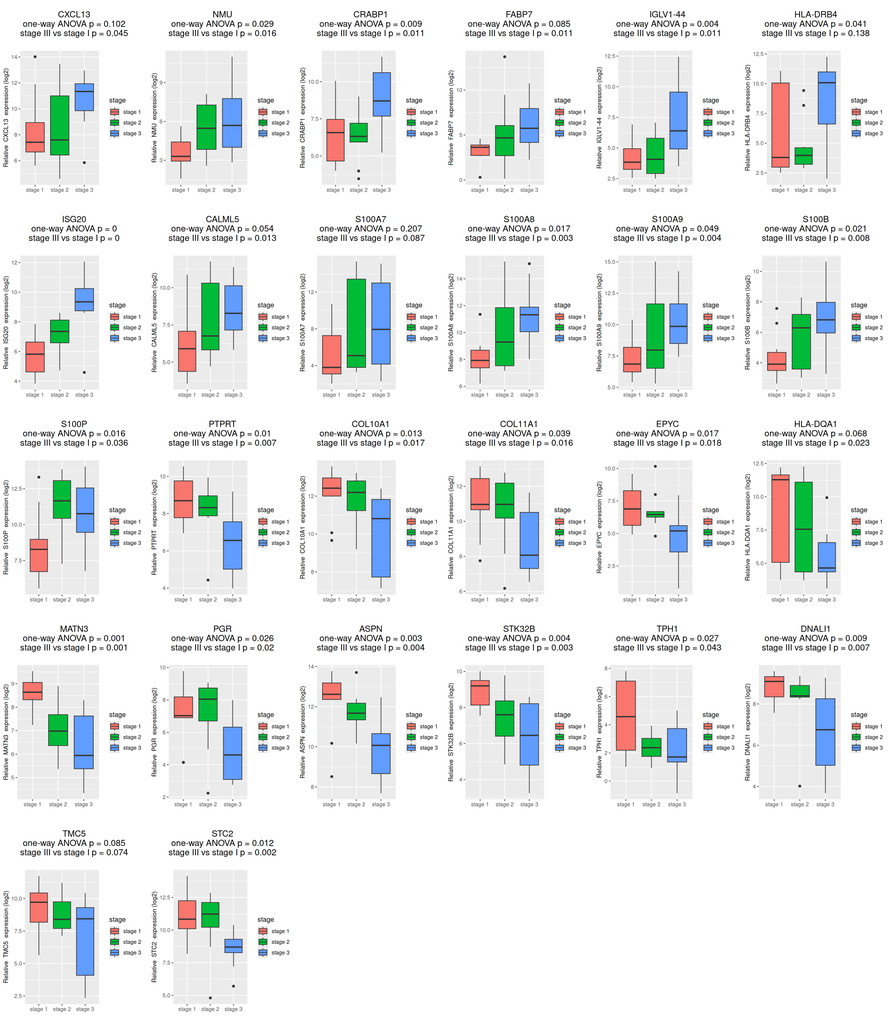

```r
box2 <- lapply(c(row.names(up), row.names(down)), function(i) {
    dd <- d[i,]
    dd$gene = rownames(dd)
    d2 <- gather(dd, sample, expr, 1:30)

    ## 通过sample名，衍生出stagge变量
    ## derive the stagge variable from the sample name.
    d2$stage <- paste('stage', sub(".*_(\\d)$", "\\1", d2$sample))

    ## 用one way anova计算 p value
    ## calculate p value with one way anova
    res <- aov(expr ~ stage, data = d2)
    pv1 <- summary(res)[[1]]$'Pr(>F)'[1]
    pv1.lab <- paste("one-way ANOVA p =", round(pv1,3))

    ## t检验用于比较第3阶段与第1阶段
    ## t test for comparing stage 3 vs stage 1
    pv2 <- t.test(expr~stage, data=subset(d2, stage!='stage 2'))$p.value
    pv2.lab <- paste("stage III vs stage I p =", round(pv2, 3))

    lab <- paste(dd$gene, pv1.lab, pv2.lab, sep="\n")

    label <- ggdraw() + draw_label(lab)
    plot_grid(label,
              ggplot(d2, aes(stage, expr, fill=stage)) +
                geom_boxplot() +
                xlab("") +
                ylab(paste("Relative ",dd$gene," expression (log2)")) +
                theme(axis.title.y = element_text(size = 10)), #调整y轴标题字号 adjust y-axis title font size
              ncol=1, rel_heights=c(.3, 1))
})

plot_grid(plotlist=box2, ncol=6)
```

```r
ggsave(file="box3.pdf")
```